# Assignment 3: U.S. Senators on Twitter

Vigya Shrote

# Network Analysis of U.S. Senate Tweets

## Overview

Twitter is a great tool to analyze the public interactions of political actors. For this assignment, I want you to use the information about who follows whom on Twitter as well as past tweets of the current U.S. Senate members to analyze how they interact and what they tweet about.

## Data

#### Twitter Handles of Senators

Twitter does not allow us to search for past tweets based on keywords, location, or topics (hashtags). However, we are able to obtain the past tweets of users if we specify their Twitter handle. The file `senators_twitter.csv` contains the Twitter handles of the current U.S. Senate members (obtained from [SocialSeer](https://www.socialseer.com/resources/us-senator-twitter-accounts/)). We will focus on the Senators’ *official Twitter accounts* (as opposed to campaign or staff members). I have also added information on the party affiliation of the Senators from [here](https://ballotpedia.org/List_of_current_members_of_the_U.S._Congress).

#### Followers

The file `senators_follow.csv` contains an edge list of connections between each pair of senators who are connected through a follower relationship (this information was obtained using the function `rtweet::lookup_friendships`). The file is encoded such that the `source` is a follower of the `target`. You will need to use the subset of `following = TRUE` to identify the connections for which the `source` follows the `target`.

#### Tweets by Senators

The data contains about 170k tweets and about 40 variables. Please note, that the API limit of 3,200 tweets per twitter handle actually cuts down the time period we can observe the most prolific Twitter users in the Senate down to only about one year into the past.

## Tasks for the Assignment

### 1. Who follows whom?

#### a) Network of Followers

Read in the edgelist of follower relationships from the file `senators_follow.csv`. Create a directed network graph. Identify the three senators who are followed by the most of their colleagues (i.e. the highest “in-degree”) and the three senators who follow the most of their colleagues (i.e. the highest “out-degree”). [Hint: You can get this information simply from the data frame or use `igraph` to calculate the number of in and out connections: `indegree = igraph::degree(g, mode = "in")`.] Visualize the network of senators. In the visualization, highlight the party ID of the senator nodes with an appropriate color (blue = Democrat, red = Republican) and size the nodes by the centrality of the nodes to the network. Briefly comment.

```r
twitter <- read.csv("/Users/vigyashrote/Desktop/DV/DV_NYU_course_material-master_last/Exercises/10_twitter_senate/senators_twitter.csv", stringsAsFactors = FALSE)

senate_follow <- read.csv("/Users/vigyashrote/Desktop/DV/DV_NYU_course_material-master_last/Exercises/10_twitter_senate/senators_follow.csv", stringsAsFactors = FALSE)

senate_follow_true<- filter(senate_follow,followed_by=="TRUE" )

top_sen <- senate_follow_true %>% group_by(source)%>% dplyr::count("target")
top_sen<- arrange(top_sen,desc(n))
top_sen<- head(top_sen,100)

senate_follow_true_merge<-  merge(senate_follow_true,top_sen , by="source")

senate_follow_true_merge <- merge(senate_follow_true_merge, twitter, by.x="source", by.y="Official.Twitter")

senate_follow_true_merge <- merge(senate_follow_true_merge, twitter, by.x="target", by.y="Official.Twitter")

senate_follow_true_merge$source <- ifelse(senate_follow_true_merge$Party.affiliation.x == "Democratic Party", paste("D",senate_follow_true_merge$source, sep = "-"), paste("R",senate_follow_true_merge$source, sep = "-"))


senate_follow_true_merge$target <- ifelse(senate_follow_true_merge$Party.affiliation.y == "Democratic Party", paste("D",senate_follow_true_merge$target, sep = "-"), paste("R",senate_follow_true_merge$target, sep = "-"))


data_el1=data.frame(
    source=c(senate_follow_true_merge$source),
    target=c(senate_follow_true_merge$target)
    )


#data_el1 %>%
#  kable("html") %>%
#  kable_styling(bootstrap_options = c("striped", "hover"), full_width = T)

# create the network object
set.seed(100)
#network1=graph_from_data_frame(d=data_el1, directed=F)
network2=graph_from_data_frame(d=data_el1, directed=T)

walktrap_c <- cluster_walktrap(network2)  # find "communities"
members <- membership(walktrap_c)

senator_d3 <- igraph_to_networkD3(network2, group=members)

senator_d3$nodes$size <- centralization.degree(network2)$res


senator_d3$group <- ifelse(substr(senator_d3$group$name,1,1) == "D", 'Democrats','Republicans')


ColourScale <- 'd3.scaleOrdinal()
            .domain(["Democrats", "Republicans"])
           .range(["blue", "maroon"]);'


plot_1a <- forceNetwork(Links = senator_d3$links, Nodes = senator_d3$node,Source = 'source', Target = 'target',NodeID = 'name',Group = 'group',charge = -50, # node repulsion
    Nodesize = 'size',linkDistance = 20,zoom = T,opacity = 1,fontSize=24,colourScale = JS(ColourScale))
plot_1a %>% saveNetwork(file = 'senator_d3.html')

plot_1a
```

[interactive chart not shown]

#### b) Communities

Clusters can be seen as solution 1A. SAME AS SOLUTION 1A.

### 2. What are they tweeting about?

From now on, rely on the information from the tweets stored in `senator_tweets.RDS`.

#### a) Most Common Topics over Time

Remove all tweets that are re-tweets (`is_retweet`) and identify which topics the senators tweet about. Rather than a full text analysis, just use the variable `hashtags` and identify the most common hashtags over time. Provide a visual summary.

```r
rds_tweets<- readRDS("/Users/vigyashrote/Desktop/DV/DV_NYU_course_material-master_last/Exercises/10_twitter_senate/senator_tweets.RDS")

senator_tweets_not_retweet<- filter(rds_tweets, is_retweet=="FALSE")
rds_tweets1<- rds_tweets

rds_tweets1$created_at <- substr(rds_tweets1$created_at, 1, 4)


hash_counts <- unnest(rds_tweets1, hashtags) %>% dplyr::group_by(created_at) %>%
  dplyr::count(hashtags, sort=TRUE)%>%
  filter(!is.na(hashtags))

hash_counts_2 <- hash_counts %>%
  group_by(created_at) %>%
  top_n(n = 1) %>%
  unnest() %>%
  arrange(desc(created_at))

plot_most_tweeted_topics<- ggplot(data= hash_counts_2, aes(x= hashtags, y= n))+geom_bar(position="dodge", stat="identity")+theme_economist()+theme(axis.text.x = element_text(angle=90, size=rel(0.8), hjust=1))+ggtitle("Most tweeted topics over time")+ylab("no of times") +xlab("most often used topics")

#interactive
ggplotly(plot_most_tweeted_topics)
```

[interactive chart not shown]

#### b) Democrats vs. Republicans

Some tweets are as old as 10 years but for some prolific users we observe a much shorter time span of Twitter activity. Feel free to subset the data to only include more recent tweets. Using the party ID variable (`Party affiliation`), identify how the choice of topics tweeted about (again using using hashtags) differs by party and visualize that information.

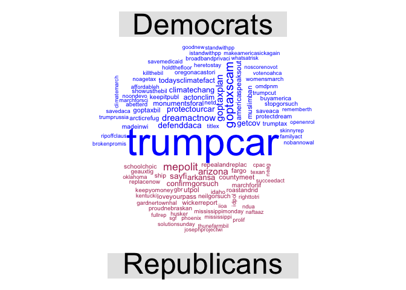

```r
rds_tweets<- readRDS("/Users/vigyashrote/Desktop/DV/DV_NYU_course_material-master_last/Exercises/10_twitter_senate/senator_tweets.RDS")

rds_tweets0<- rds_tweets
rds_tweets0$created_at <- substr(rds_tweets0$created_at, 1, 4)

senator_recent_tweets<- filter(rds_tweets0, created_at==2017)

senator_recent_tweets<- senator_recent_tweets %>% filter(!is.na(hashtags))

senator_party <- merge(senator_recent_tweets,twitter, by.x="screen_name", by.y="Official.Twitter")

tryTolower = function(x)
{
  # create missing value
  # this is where the returned value will be
  y = NA
  # tryCatch error
  try_error = tryCatch(tolower(x), error = function(e) e)
  # if not an error
  if (!inherits(try_error, "error"))
    y = tolower(x)
  return(y)
}

replacePunctuation<- function(x){
  gsub("[[:punct:]]+"," ",x)
}

create_clean_corpus <- function(text_vector){
  # Clean a text vector
  text_corpus <- VCorpus(VectorSource(text_vector))
  text_corpus_clean<-sapply(text_corpus, function(x) tryTolower(x))
  text_corpus_clean <- VCorpus(VectorSource(text_corpus_clean))
  text_corpus_clean <- tm_map(text_corpus_clean, content_transformer(tolower))
  text_corpus_clean <- tm_map(text_corpus_clean, removeNumbers)
  text_corpus_clean <- tm_map(text_corpus_clean, removeWords,c(stopwords()))
  text_corpus_clean <- tm_map(text_corpus_clean, content_transformer(replacePunctuation))
  text_corpus_clean <- tm_map(text_corpus_clean, stemDocument,language="english")
  text_corpus_clean <- tm_map(text_corpus_clean, stripWhitespace)
  return(text_corpus_clean)
}

Democrats <- paste(senator_party$hashtags[senator_party$Party.affiliation =="Democratic Party"], collapse = " ")

Republicans <- paste(senator_party$hashtags[senator_party$Party.affiliation =="Republican Party"],collapse = " ")

word_cloud_1 <- c(Democrats, Republicans)
all_hashtags<- create_clean_corpus(word_cloud_1)
all_hashtags_m <- TermDocumentMatrix(all_hashtags, control=list(weighting = weightTfIdf))
colnames(all_hashtags_m) <- c("Democrats", "Republicans")
all_hashtags_m <- as.matrix(all_hashtags_m)
comparison.cloud(all_hashtags_m, colors = c("blue", "maroon"), max.words = 100)
```

#### c) Gun Control I - Dems vs. Reps

The democratic party seems broadly more supportive of gun control legislation. Try to identify a set of 5-10 hashtags that signal support for gun control legislation (e.g. “`NeverAgain`”, `#guncontrol`, `#guncontrolnow`, `#Enough`) and others that are expressing support for the right to own guns (e.g. `#2ndamendment`, `#NRA`, `#liberals`). The site [ritetag.com](https://ritetag.com/best-hashtags-for/gun%20control) can help with that task. Using the subset of senator tweets that included these hashtags, show whether and how senators from different parties talk differently about the issue of gun legislation.

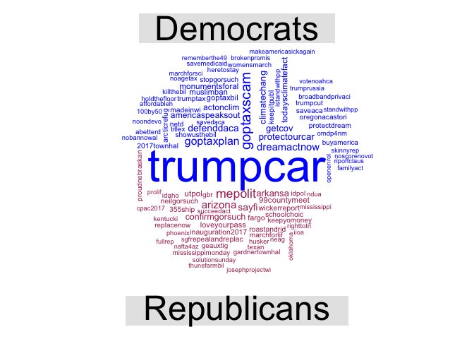

```r
list_of_hashtags <- c("NeverAgain", "neveragain", "guncontrol", "guncontrolnow", "Enough", "2ndamendment", "NRA", "liberals")

gun_control<- filter(rds_tweets, hashtags %in% list_of_hashtags)

senator_party_1 <- merge(gun_control, twitter, by.x="screen_name", by.y="Official.Twitter")


tryTolower = function(x)
{
  # create missing value
  # this is where the returned value will be
  y = NA
  # tryCatch error
  try_error = tryCatch(tolower(x), error = function(e) e)
  # if not an error
  if (!inherits(try_error, "error"))
    y = tolower(x)
  return(y)
}

replacePunctuation<- function(x){
  gsub("[[:punct:]]+"," ",x)
}

create_clean_corpus <- function(text_vector){
  # Clean a text vector
  text_corpus <- VCorpus(VectorSource(text_vector))
  text_corpus_clean<-sapply(text_corpus, function(x) tryTolower(x))
  text_corpus_clean <- VCorpus(VectorSource(text_corpus_clean))
  text_corpus_clean <- tm_map(text_corpus_clean, removeWords,c(stopwords()))
  text_corpus_clean <- tm_map(text_corpus_clean, content_transformer(replacePunctuation))
  text_corpus_clean <- tm_map(text_corpus_clean, stemDocument,language="english")
  text_corpus_clean <- tm_map(text_corpus_clean, stripWhitespace)
  return(text_corpus_clean)
}


word_cloud_2 <- c(Democrats, Republicans)
all_hashtags<- create_clean_corpus(word_cloud_2)
all_hashtags_m <- TermDocumentMatrix(all_hashtags, control=list(weighting = weightTfIdf))
colnames(all_hashtags_m) <- c("Democrats", "Republicans")
all_hashtags_m <- as.matrix(all_hashtags_m)
comparison.cloud(all_hashtags_m, colors = c("blue", "maroon"), max.words = 100)
```

#### d) Gun Control II - Parkland Shooting

On February 14, 2018, a mass shooting occurred at Marjory Stoneman Douglas High School in Parkland, Florida. Provide some visualization of how senators responded to the event in their Twitter communication.

```r
rds_tweets<- readRDS("/Users/vigyashrote/Desktop/DV/DV_NYU_course_material-master_last/Exercises/10_twitter_senate/senator_tweets.RDS")

senator_tweets_11 <- filter(rds_tweets, is_retweet=='FALSE')



senator_tweets_11$created_at <- substr(senator_tweets_11$created_at, 1, 10)

senator_tweets_22 <- filter(senator_tweets_11, senator_tweets_11$created_at > '2018-02-13')

senator_tweets_33 <- filter(senator_tweets_11, senator_tweets_11$created_at < '2018-02-17')

senator_tweets_44 <- filter(senator_tweets_33, grepl('Florida', text))

clean <- function(corpus){
  corpus <- tm_map(corpus, removePunctuation)
  corpus <- tm_map(corpus, content_transformer(tolower))
  corpus <- tm_map(corpus, removeWords, c(stopwords("en")))
  corpus <- tm_map(corpus, stripWhitespace)
  return(corpus)
}

florida_corpus<- Corpus(VectorSource(senator_tweets_44$text))

florida_tweets_clean <- clean(florida_corpus)

florida_tweets_dtm <- DocumentTermMatrix(florida_tweets_clean, control = list(weighting = function(x) weightTfIdf(x, normalize = T)))

florida_tweets_td<- tidy(florida_tweets_dtm)

florida_tweets_tf_idf <-  florida_tweets_td %>%
  bind_tf_idf(term, document, count) %>%
  arrange(desc(tf_idf))
head(florida_tweets_tf_idf)
```

```
## # A tibble: 6 x 6
##   document term               count    tf   idf tf_idf
##   <chr>    <chr>              <dbl> <dbl> <dbl>  <dbl>
## 1 268      httpstco4d8wanbkna  2.97 0.657  6.18   4.06
## 2 240      httpstcokmvfrs6c4n  2.97 0.554  6.18   3.42
## 3 315      httpstcoe2qowpisc5  2.97 0.540  6.18   3.34
## 4 363      everyones           2.23 0.450  6.18   2.78
## 5 279      httpstcobn3unocbdf  2.23 0.448  6.18   2.77
## 6 315      comes               2.44 0.444  5.08   2.26
```

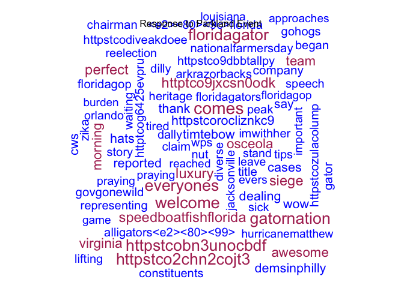

```r
#word cloud
set.seed(150)
par(bg="white")
wordcloud(florida_tweets_tf_idf$term, florida_tweets_tf_idf$count, max.words = 100, colors = c("blue", "maroon"), scale =c(2,.7))
text(x=0.5, y=0.95,"Response to Parkland Event ")
```

### 3. Are you talking to me?

Select the set of re-tweeted messages from other senators and identify the source of the originating message. Calculate by senator the amount of re-tweets they received and from which party these re-tweets came. Essentially, I would like to visualize whether senators largely re-tweet their own party colleagues’ messages or whether there are some senators that get re-tweeted on both sides of the aisle. Visualize the result.

[figure not shown]

```r
tweets_re <- filter(rds_tweets, is_retweet == TRUE)

re_1 <- unnest(tweets_re, mentions_screen_name) %>% group_by(screen_name)

re_1_1 <- filter(re_1, mentions_screen_name %in% twitter$Official.Twitter)
#re_2 <- data.frame(re_1_1$screen_name,re_1_1$mentions_screen_name)

#re_2<- filter(re_2,screen_name != mentions_screen_name )

re_2 <- sqldf("select screen_name,mentions_screen_name from re_1_1 where screen_name != mentions_screen_name")

merge_re <- merge(x = re_2, y = twitter, by.x = "screen_name", by.y = "Official.Twitter")

merge_re$Party_screen <- merge_re$Party.affiliation

merge_re1 <- merge(x = merge_re, y = twitter, by.x = "mentions_screen_name", by.y = "Official.Twitter")

merge_re1$Party_mentioned <- merge_re1$Party.affiliation.y

c_re <- c("screen_name", "Party_screen", "mentions_screen_name", "Party_mentioned")

answer_3a <- merge_re1[c_re]

answer_3a1 <- answer_3a %>% group_by(Party_screen) %>%
  dplyr::count(Party_mentioned, sort=TRUE)

plot_3a<- ggplot(data = answer_3a1 , aes(x = Party_screen, y = n, fill =Party_mentioned)) +
  geom_bar(position="dodge", stat="identity",show.legend = TRUE) +
  ylab("# of Retweets")+
  xlab("Party Name")+
 theme_economist()+
  scale_fill_manual(values = c("blue", "green", "maroon" ))+
  theme(panel.grid.major = element_blank(), panel.grid.minor = element_blank(),axis.text.x = element_text(angle=90, size=rel(1), hjust=1))+ ggtitle("Retweets by senators")

plot_3a
```

#### b) Identifying Mentions

Identify the tweets in which one senator mentions another senator directly (the variable is `mentions_screen_name`). For this example, please remove simple re-tweets (`is_retweet == FALSE`). Calculate who re-tweets whom among the senate members. Convert the information to an undirected graph object in which the number of mentions is the strength of the relationship between senators. Visualize the network graph using the party identification of the senators as a group variable (use blue for Democrats and red for Republicans) and some graph centrality measure to size the nodes. Comment on what you can see from the visualization.

```r
rds_tweets<- readRDS("/Users/vigyashrote/Desktop/DV/DV_NYU_course_material-master_last/Exercises/10_twitter_senate/senator_tweets.RDS")


senator_3b <- filter(rds_tweets, is_retweet=='FALSE')

senator_3b <- filter(senator_3b, !is.na(mentions_screen_name))

senator_3b_tweets <- cSplit(senator_3b, "mentions_screen_name", sep = ",", direction = "long")

senator_3b_tweets$mentions_screen_name <- gsub("(", ",", senator_3b_tweets$mentions_screen_name, fixed=TRUE)

senator_3b_tweets$mentions_screen_name <- gsub(")", ",", senator_3b_tweets$mentions_screen_name, fixed=TRUE)

senator_3b_tweets$mentions_screen_name <- gsub("c,", "", senator_3b_tweets$mentions_screen_name, fixed=TRUE)

senator_3b_tweets$mentions_screen_name <- gsub(",", "", senator_3b_tweets$mentions_screen_name, fixed=TRUE)

senator_3b_tweets$mentions_screen_name <- gsub('"', "", senator_3b_tweets$mentions_screen_name, fixed=TRUE)

senator_3b_merge <- merge(senator_3b_tweets, twitter, by.x="mentions_screen_name", by.y="Official.Twitter")

tweets_3b <- senator_3b_merge %>%
  filter(!(mentions_screen_name == screen_name)) %>%
  group_by(screen_name, mentions_screen_name) %>%
  dplyr::summarise(Total_number_of_mentions = n()) %>%
  arrange(-Total_number_of_mentions)

tweets_3b
```

```
## # A tibble: 3,844 x 3
## # Groups:   screen_name [100]
##    screen_name     mentions_screen_name Total_number_of_mentions
##    <chr>           <chr>                                   <int>
##  1 SenThadCochran  SenatorWicker                             213
##  2 SenAngusKing    SenatorCollins                            133
##  3 SenatorHassan   SenatorShaheen                            132
##  4 SenatorWicker   SenThadCochran                            128
##  5 JeffFlake       SenJohnMcCain                             101
##  6 SenatorEnzi     SenJohnBarrasso                            98
##  7 SenatorCollins  SenAngusKing                               86
##  8 MikeCrapo       SenatorRisch                               84
##  9 SenatorMenendez CoryBooker                                 84
## 10 SenToomey       SenBobCasey                                76
## # ... with 3,834 more rows
```

[figure not shown]

```r
tweets_rel<- data.frame(source=c(tweets_3b$screen_name),target=c(tweets_3b$mentions_screen_name),
weight=c(tweets_3b$Total_number_of_mentions))

network_3b=graph_from_data_frame(d=tweets_rel, directed=F)

plot_3b_lay = layout.fruchterman.reingold(network_3b)
par(bg="gray15", mar=c(1,1,1,1))
plot(network_3b, layout=plot_3b_lay,
     vertex.color="gray25",
     vertex.size=(degree(network_3b, mode = "in")),
     vertex.label.family="sans",
     vertex.shape="circle",  #can also try "square", "rectangle", etc. More in igraph manual
     vertex.label.color=hsv(h=0, s=0, v=.95, alpha=0.5),
     vertex.label.cex=(degree(network_3b, mode = "in"))/300, #sized by in-degree centrality
     edge.arrow.size=0.8,
     edge.arrow.width=0.5,
     edge.width=edge_attr(network_3b)$n/10, #sized by edge weight
     edge.color=hsv(h=.95, s=1, v=.7, alpha=0.5))
title("Retweet Network", cex.main=1, col.main="gray95")
```

```r
walktrap_c <- cluster_walktrap(network_3b)  # find "communities"
members <- membership(walktrap_c)

senator_d3 <- igraph_to_networkD3(network_3b, group=members)
senator_d3$nodes$size <- centralization.degree(network_3b)$res
#senator_d3$group <- ifelse(substr(senator_d3$group$name,1,1) == "D", 'Democrats','Republicans')

ColourScale <- 'd3.scaleOrdinal()
            .domain(["Democrats", "Republicans"])
           .range(["maroon", "blue"]);'

plot_3b_net <- forceNetwork(Links = senator_d3$links, Nodes = senator_d3$node,
                  Source = 'source', Target = 'target',
                  NodeID = 'name',
                  Group = 'group', # color nodes by group calculated earlier
                  charge = -50, # node repulsion
                  Nodesize = 'size',
                  linkDistance = 20,
                  zoom = T,
                  opacity = 1,
                  fontSize=24
                  #colourScale = JS(ColourScale)
                  )
plot_3b_net %>% saveNetwork(file = 'senator_d3.html')

plot_3b_net
```

[interactive chart not shown]

#### c) BONUS ONLY: Who is popular on Twitter?

Using the twitter handles, access the user information of the senators to identify the number of followers they have (obviously, this will require to actually connect to the Twitter server). Re-do the previous graph object but now use the number of followers (or some transformation of that info) to size the nodes. Comment how graph degree centrality (via mentions) and the number of followers are related.

## Submission

Please follow the instructions to submit your homework. The homework is due on Thursday, April 12.

## Please stay honest!

If you do come across something online that provides part of the analysis / code etc., please no wholesale copying of other ideas. We are trying to evaluate your abilities to visualized data not the ability to do internet searches. Also, this is an individually assigned exercise – please keep your solution to yourself.